# data_analysis

```python
%pip install scanpy
```

```python
%pip install leidenalg
```

### Gene Expression Data Analysis

@Author: wangyanli(wangyanli1@genomics.cn) \ @Created time: 2022.09.02

This is the answer notebook to the code test.

Requirements:

- 降维
- 聚类
- (Advanced): 寻找每个类样本的特征基因并通过特征基因对该类样本进行注释

小结：

- 原矩阵： 46,376 rows(samples) x 19,782 colums (genes)；过滤处理后：1305 × 11361
- 通过PCA/UMAP对原基因表达矩阵进行降维，选择 10 PCs
- 使用Leiden图算法对数据进行聚类，尝试分成 9 类，但差异性分析后特征基因有不同聚类间重叠，减少聚类数为 4 类
- 根据特征基因对聚类进行标注

存在问题/改进方向（需要进一步验证或分析）：

- 数据处理：如何定义“low-quality”的阈值；对线粒体基因的处理方式
- 聚类：聚类数确定
- 差异性分析：LR与Wilcoxon秩和检验两种算法结果的对比

```python
#### Loading pkgs
import sys
sys.path.append('/home/aistudio/external-libraries')

import numpy as np
import pandas as pd
import scanpy as sc
import warnings
import matplotlib.pyplot as plt

results_file = 'write/gene_expression_csvs'

%matplotlib inline
from IPython.core.interactiveshell import InteractiveShell
InteractiveShell.ast_node_interactivity = "all"

warnings.filterwarnings("ignore")
```

#### 0. EDA (Explore Data Analysis)

Actually, I am new to this domain so this work highly referred the Scanpy guide document.

Ref:\ https://scanpy-tutorials.readthedocs.io/en/latest/pbmc3k.html

```python
# To do better visualization, use AI studio; import data from Baidu Netdisk
data = pd.read_csv('./data/data167200/expression_matrix.csv', index_col=0)
```

```python
# Transpose, required by the Scanpy object structure
data.T.describe()
```

| Row | 0610005C13Rik | 0610007P14Rik | 0610009B22Rik | 0610009E02Rik | 0610009L18Rik | 0610009O20Rik | 0610010F05Rik | 0610010K14Rik | 0610011F06Rik | 0610025J13Rik | ... | mt-Tt | mt-Tv | n-R5-8s1 | n-R5s173 | n-R5s204 | n-R5s216 | n-R5s33 | n-R5s48 | n-R5s88 | n-R5s95 |
| --- | --- | --- | --- | --- | --- | --- | --- | --- | --- | --- | --- | --- | --- | --- | --- | --- | --- | --- | --- | --- | --- |
| count | 46376.000000 | 46376.000000 | 46376.000000 | 46376.000000 | 46376.000000 | 46376.000000 | 46376.000000 | 46376.000000 | 46376.000000 | 46376.000000 | ... | 46376.000000 | 46376.000000 | 46376.000000 | 46376.000000 | 46376.000000 | 46376.000000 | 46376.000000 | 46376.000000 | 46376.000000 | 46376.0 |
| mean | 0.000043 | 0.008453 | 0.004701 | 0.000323 | 0.000733 | 0.001790 | 0.003364 | 0.000431 | 0.007763 | 0.000022 | ... | 0.003299 | 0.024388 | 0.004420 | 0.000022 | 0.000022 | 0.000022 | 0.000022 | 0.000022 | 0.000022 | 0.0 |
| std | 0.006567 | 0.097923 | 0.071484 | 0.019143 | 0.027067 | 0.043771 | 0.060452 | 0.020762 | 0.093244 | 0.004644 | ... | 0.058091 | 0.159069 | 0.066987 | 0.004644 | 0.004644 | 0.004644 | 0.004644 | 0.004644 | 0.004644 | 0.0 |
| min | 0.000000 | 0.000000 | 0.000000 | 0.000000 | 0.000000 | 0.000000 | 0.000000 | 0.000000 | 0.000000 | 0.000000 | ... | 0.000000 | 0.000000 | 0.000000 | 0.000000 | 0.000000 | 0.000000 | 0.000000 | 0.000000 | 0.000000 | 0.0 |
| 25% | 0.000000 | 0.000000 | 0.000000 | 0.000000 | 0.000000 | 0.000000 | 0.000000 | 0.000000 | 0.000000 | 0.000000 | ... | 0.000000 | 0.000000 | 0.000000 | 0.000000 | 0.000000 | 0.000000 | 0.000000 | 0.000000 | 0.000000 | 0.0 |
| 50% | 0.000000 | 0.000000 | 0.000000 | 0.000000 | 0.000000 | 0.000000 | 0.000000 | 0.000000 | 0.000000 | 0.000000 | ... | 0.000000 | 0.000000 | 0.000000 | 0.000000 | 0.000000 | 0.000000 | 0.000000 | 0.000000 | 0.000000 | 0.0 |
| 75% | 0.000000 | 0.000000 | 0.000000 | 0.000000 | 0.000000 | 0.000000 | 0.000000 | 0.000000 | 0.000000 | 0.000000 | ... | 0.000000 | 0.000000 | 0.000000 | 0.000000 | 0.000000 | 0.000000 | 0.000000 | 0.000000 | 0.000000 | 0.0 |
| max | 1.000000 | 3.000000 | 3.000000 | 2.000000 | 1.000000 | 2.000000 | 2.000000 | 1.000000 | 3.000000 | 1.000000 | ... | 2.000000 | 4.000000 | 2.000000 | 1.000000 | 1.000000 | 1.000000 | 1.000000 | 1.000000 | 1.000000 | 0.0 |

8 rows × 19782 columns

Note the "max" row, since no obviously large value here, from the values pattern, I guess it should have done transformed.

```python
data.T[['mt-Rnr2']].max() # mt-Rnr2 is the most expressed gene found through EDA
```

```
Row
mt-Rnr2    373
dtype: int64
```

```python
sorted(data.T.max().tolist())[-10:] # the max 10 counts from the raw gene expression matrix
```

```
[21, 26, 29, 30, 36, 45, 80, 85, 178, 373]
```

```python
data.shape
```

```
(19782, 46376)
```

```python
### Use Scanpy and create an object
geneinfo = pd.DataFrame(data.index,index=data.index,columns=['genes_index'])
cellinfo = pd.DataFrame(data.columns,index=data.columns,columns=['samples_index'])
```

```python
### Create anndata object
### https://anndata.readthedocs.io/en/latest/
# drop the raw dataframe to reduce memory use:
#data.drop(data.index,inplace=True)
#del data
adata = sc.AnnData(data.T, obs=cellinfo, var=geneinfo) # transpose
```

```python
print("The number of observations (samples) is: ", adata.obs.shape[0]) # 46376 samples
print("The number of variables (genes) is: ", adata.var.shape[0]) # 19782 genes
print(adata.to_df().shape) # (46376, 19782)
```

```
The number of observations (samples) is:  46376
The number of variables (genes) is:  19782
(46376, 19782)
```

The raw gene expression matrix is gene(row) x sample(col). The transposed anndata contais 46,376 rows(samples) x 19,782 colums (genes).

```python
geneinfo.index
```

```
Index(['0610005C13Rik', '0610007P14Rik', '0610009B22Rik', '0610009E02Rik',
       '0610009L18Rik', '0610009O20Rik', '0610010F05Rik', '0610010K14Rik',
       '0610011F06Rik', '0610025J13Rik',
       ...
       'mt-Tt', 'mt-Tv', 'n-R5-8s1', 'n-R5s173', 'n-R5s204', 'n-R5s216',
       'n-R5s33', 'n-R5s48', 'n-R5s88', 'n-R5s95'],
      dtype='object', name='Row', length=19782)
```

```python
cellinfo.index
```

```
Index(['CGTACAATTTTTTT', 'TTCGTTATTTTTTT', 'CAAACCAACCCCCC', 'TCTTTTCACCCCCC',
       'GGATTGAACCCCCC', 'GAGACAAACCCCCC', 'CGGGACCAGGGGGG', 'CTTGGGAAGGGGGN',
       'CTAACGTAGGGGGG', 'AGCCGTTAGGGGGN',
       ...
       'ACGGGTGTCGCGCN', 'ATAACCATCGCGCT', 'CGCGCAGTCGCGTC', 'AGTACGCTGCGGCT',
       'CTGGACATTATCGN', 'GTGACTGTTATATA', 'CTGCGAATCGCGAT', 'TCTCAACTCGCGCG',
       'AAGCCCATCGCGCN', 'AGATTGTTTATCGC'],
      dtype='object', length=46376)
```

##### Data Processing

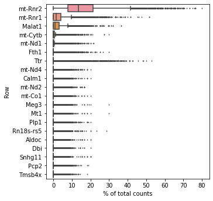

```python
# Top n high expressed genes; Note mt genes
sc.pl.highest_expr_genes(adata, n_top=20, )
```

```python
# Filter low-quality cells: few expressed genes
sc.pp.filter_cells(adata, min_genes=200)
sc.pp.filter_genes(adata, min_cells=3)
```

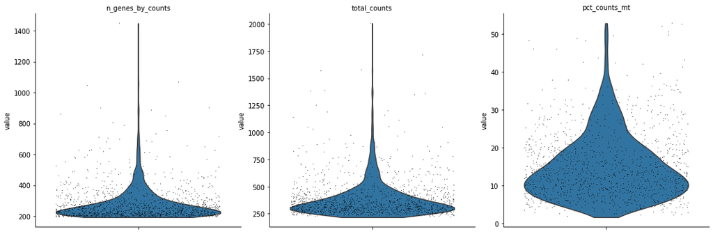

```python
adata.var['mt'] = adata.var_names.str.startswith('mt-')  # remark mitochondrial genes as mt
sc.pp.calculate_qc_metrics(adata, qc_vars=['mt'], percent_top=None, log1p=False, inplace=True)
# n_genes_by_counts： The number of genes with at least 1 count in a cell. Calculated for all cells
# total_counts： Total number of counts for a cell
# pct_counts_mt: Proportion of total counts for a cell which are mitochondrial
sc.pl.violin(adata, ['n_genes_by_counts', 'total_counts', 'pct_counts_mt'],
                jitter=0.4, multi_panel=True)
```

The thrid violin plot (pct_counts_mt) shows a great amount of mitochondrial genes proportion exceeds 10%.\ This line could be used to filter high mt count: `adata = adata[adata.obs.pct_counts_mt < 10, :]`

Ref:

1. https://scanpy.readthedocs.io/en/stable/generated/scanpy.pp.calculate_qc_metrics.html

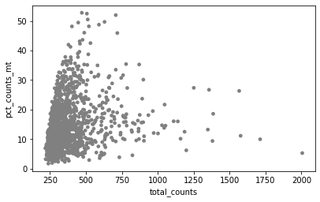

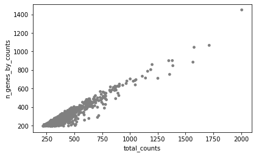

```python
sc.pl.scatter(adata, x='total_counts', y='pct_counts_mt')
sc.pl.scatter(adata, x='total_counts', y='n_genes_by_counts')
```

```python
# Remove cells that have too many mt-genes expressed or too many total counts ("outliers" from the above plots)
#adata = adata[adata.obs.pct_counts_mt < 50, :] # Here for the threshold, I have a doubt, needs further investigation
adata_raw = adata.copy() # copy
adata = adata[adata.obs.n_genes_by_counts < 800, :]
adata = adata[adata.obs.pct_counts_mt < 40, :]
```

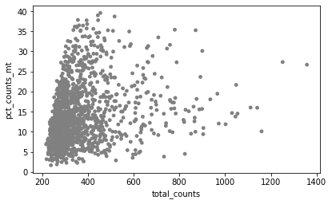

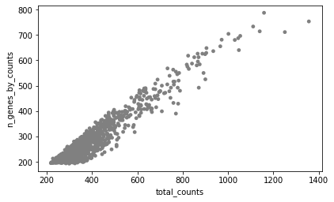

```python
sc.pl.scatter(adata, x='total_counts', y='pct_counts_mt')
sc.pl.scatter(adata, x='total_counts', y='n_genes_by_counts')
```

The first scatter plot shows that there is no obvious relationship between `pct_counts_mt` and `total_counts`, which is the normal case. In general, the propotion of mitochondrial genes is stable in each certain type of cells.

The second scatter plot indicates a linear relationship between `n_genes_by_counts` and `total_counts`, this correlation is reasonable.

```python
# Log transformation
sc.pp.log1p(adata)
# Write data
#adata.raw = adata # can get back the object in by calling .AnnData.raw.raw.to_adata()
#adata.write_csvs(results_file, )
```

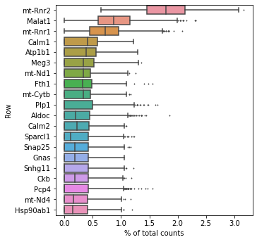

```python
sc.pl.highest_expr_genes(adata, n_top=20, )
#  High expression levels of mitochondrial genes could be an indicator of: poor sample quality; biology of the particular sample, for example, tumor biopsies
```

```python
adata.var
```

| Row | genes_index | n_cells | mt | n_cells_by_counts | mean_counts | pct_dropout_by_counts | total_counts |
| --- | --- | --- | --- | --- | --- | --- | --- |
| 0610007P14Rik | NaN | 69 | False | 69 | 0.059354 | 94.815928 | 79.0 |
| 0610009B22Rik | NaN | 31 | False | 31 | 0.024793 | 97.670924 | 33.0 |
| 0610009E02Rik | NaN | 4 | False | 4 | 0.003005 | 99.699474 | 4.0 |
| 0610009O20Rik | NaN | 9 | False | 9 | 0.006762 | 99.323817 | 9.0 |
| 0610010F05Rik | NaN | 27 | False | 27 | 0.023291 | 97.971450 | 31.0 |
| ... | ... | ... | ... | ... | ... | ... | ... |
| mt-Tr | NaN | 17 | True | 17 | 0.012772 | 98.722765 | 17.0 |
| mt-Ts2 | NaN | 40 | True | 40 | 0.030804 | 96.994741 | 41.0 |
| mt-Tt | NaN | 23 | True | 23 | 0.018032 | 98.271976 | 24.0 |
| mt-Tv | NaN | 131 | True | 131 | 0.109692 | 90.157776 | 146.0 |
| n-R5-8s1 | NaN | 17 | False | 17 | 0.012772 | 98.722765 | 17.0 |

11361 rows × 7 columns

```python
adata
```

```
AnnData object with n_obs × n_vars = 1305 × 11361
    obs: 'samples_index', 'n_genes', 'n_genes_by_counts', 'total_counts', 'total_counts_mt', 'pct_counts_mt'
    var: 'genes_index', 'n_cells', 'mt', 'n_cells_by_counts', 'mean_counts', 'pct_dropout_by_counts', 'total_counts'
    uns: 'log1p'
```

#### 1. Dimension Reduction

Here I choose UMAP to reduce the dimension of gene expression data.

UMAP (Uniform Manifold Approximation and Projection) is a manifold learning technique, highly recommended by Scanpy, which is suitable for visualizing high-dimensional data:

- compared with PCA, UMAP can expect non-linear relationships. In PCA, each PC contributes to explaining some proportion of total variance, while the UMAP1, UMAP2, or etc. don't have practical meaning.
- compared with tSNE (another manifold learning method), UMAP runs faster and is less computing-tensive. UMAP updates the optimization way from gradient descent(GD) to stochastic gradient descent(SGD). In practice, the UMAP performance appears to linearly while tSNE scales exponationally.
- compared with tSNE, UMAP could also maintain the global structure as well as the original topology.

Ref:

1. https://scanpy.readthedocs.io/en/stable/generated/scanpy.tl.umap.html
2. https://arxiv.org/pdf/1802.03426.pdf
3. https://www.nature.com/articles/nbt.4314

##### 1.1 PCA

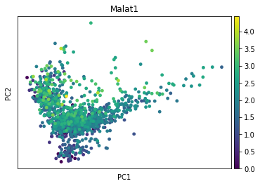

```python
# Just try PCA at the beginning
# solvers: 'arpack' - efficient computation of the principal components of a sparse matrix
sc.tl.pca(adata, svd_solver='arpack')
sc.pl.pca(adata, color=["Malat1"]) # coloring expression of a given gene
```

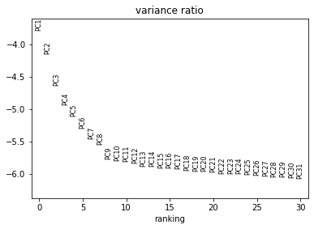

```python
sc.pl.pca_variance_ratio(adata, log=True)
```

From the elbow plot, I suppose the ‘elbow’ occurs around 9 to 12, here 10 PCs are decided to represent the majority variance.

##### 1.2 UMAP

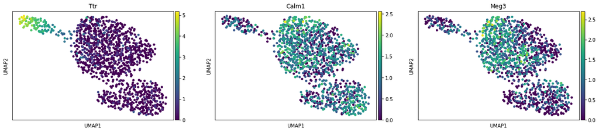

```python
# Using default settings
sc.pp.neighbors(adata, n_neighbors=15) # n_neighbors: The size of local neighborhood; default: 15 , n_pcs=0
sc.tl.umap(adata)
sc.pl.umap(adata, color=['Ttr', 'Calm1', 'Meg3'], use_raw=False)
#sc.pl.umap(adata, color=['Ttr', 'Calm1', 'Meg3'], use_raw=True)
#sc.pl.umap(adata)
```

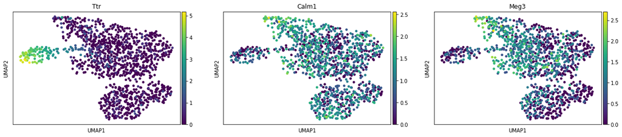

```python
# Using parameter n_pcs defined by the elbow plot
sc.pp.neighbors(adata, n_neighbors=15, n_pcs=10)
sc.tl.umap(adata)
sc.pl.umap(adata, color=['Ttr', 'Calm1', 'Meg3'], use_raw=False)
```

#### 2. Clustering

Leiden graph-clustering method is utilized, recommended by Scanpy.

Compared with Louvain algorithm, one of the most common algorithms for uncovering community structure, Leiden method updates the previous one to overcome the cases where some of the communities found by Louvain are badly connected. It is also proven that all subsets of all communities are locally optimally partitioned, in addition to a faster convergence rate.

Ref:

1. https://arxiv.org/abs/1810.08473

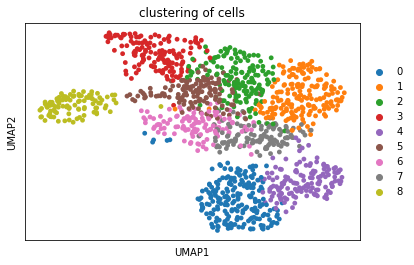

```python
sc.tl.leiden(adata, resolution=1, key_added="clusters") # resolution: default: 1; A parameter value controlling the coarseness of the clustering. Higher values lead to more clusters.
sc.pl.umap(adata,color="clusters", title='clustering of cells')
```

Change `resolution` to "merge" the clusters. Since the subsequent analysis of genetic differences between clusters found that there were some overlaps between clusters, it was decided to lower this parameter.

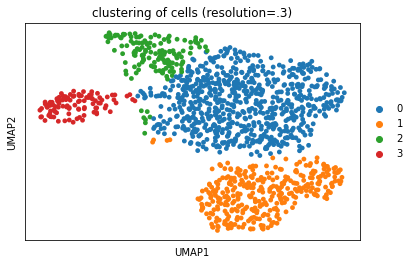

```python
# change resolution - fair performance
sc.tl.leiden(adata, resolution=.3, key_added="clusters") # resolution: default: 1; A parameter value controlling the coarseness of the clustering. Higher values lead to more clusters.
sc.pl.umap(adata,color="clusters", title='clustering of cells (resolution=.3)')
```

#### 3. Features Selection

To identify marker genes, testing on three methods.

```python
# recap anndata
adata
```

```
AnnData object with n_obs × n_vars = 1305 × 11361
    obs: 'samples_index', 'n_genes', 'n_genes_by_counts', 'total_counts', 'total_counts_mt', 'pct_counts_mt', 'clusters'
    var: 'genes_index', 'n_cells', 'mt', 'n_cells_by_counts', 'mean_counts', 'pct_dropout_by_counts', 'total_counts'
    uns: 'log1p', 'pca', 'neighbors', 'umap', 'leiden', 'clusters_colors'
    obsm: 'X_pca', 'X_umap'
    varm: 'PCs'
    obsp: 'distances', 'connectivities'
```

##### 3.1 T-test

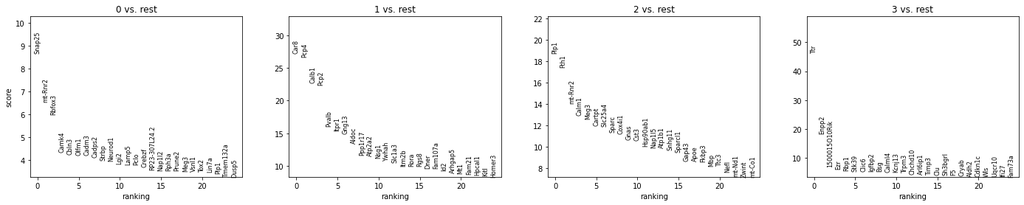

```python
# T-test
sc.tl.rank_genes_groups(adata, 'clusters', method='t-test')
sc.pl.rank_genes_groups(adata, n_genes=25, sharey=False)
```

##### 3.2 Logistic regression

LR uses a multi-variate appraoch whereas conventional differential tests are uni-variate.

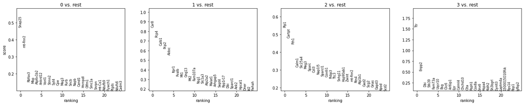

```python
# logistic regression
# LR Ref: https://www.biorxiv.org/content/10.1101/258566v2
sc.tl.rank_genes_groups(adata, 'clusters', method='logreg')
sc.pl.rank_genes_groups(adata, n_genes=25, sharey=False)
```

```python
pd.DataFrame(adata.uns['rank_genes_groups']['names']).head(5)
```

|  | 0 | 1 | 2 | 3 |
| --- | --- | --- | --- | --- |
| 0 | Snap25 | Car8 | Plp1 | Ttr |
| 1 | mt-Rnr2 | Pcp4 | Cartpt | Enpp2 |
| 2 | Rbfox3 | Calb1 | Fth1 | Dbi |
| 3 | Mbp | Pcp2 | Calm1 | Stk39 |
| 4 | Atp6v1b2 | Aldoc | Slc25a4 | Fam73a |

##### 3.3 Wilcoxon rank sum test

Recall the assumptions of the two-sample T-test, it requires the following assumptions:

1. Two samples are independent of one another
2. Two populations have equal variance
3. Two populations are normally distributed

Ref:\ https://data.library.virginia.edu/the-wilcoxon-rank-sum-test/

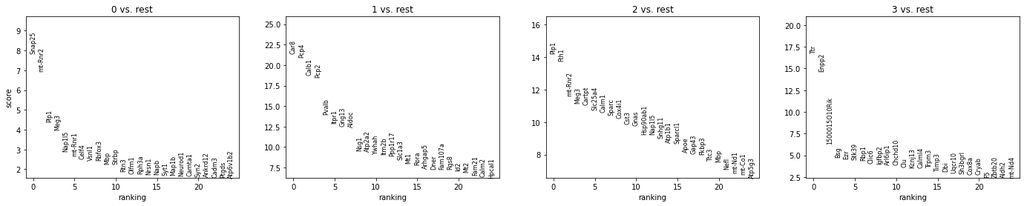

```python
# Scanpy recommending using Wilcoxon rank-sum (Mann-Whitney-U) test
sc.tl.rank_genes_groups(adata, 'clusters', method='wilcoxon')
sc.pl.rank_genes_groups(adata, n_genes=25, sharey=False)
```

```python
pd.DataFrame(adata.uns['rank_genes_groups']['names']).head(5)
```

|  | 0 | 1 | 2 | 3 |
| --- | --- | --- | --- | --- |
| 0 | Snap25 | Car8 | Plp1 | Ttr |
| 1 | mt-Rnr2 | Pcp4 | Fth1 | Enpp2 |
| 2 | Plp1 | Calb1 | mt-Rnr2 | 1500015O10Rik |
| 3 | Meg3 | Pcp2 | Meg3 | Bsg |
| 4 | Nap1l5 | Pvalb | Cartpt | Ezr |

```python
# check the marker genes within first cluster (group 0)
sc.get.rank_genes_groups_df(adata, group="0")
```

|  | names | scores | logfoldchanges | pvals | pvals_adj |
| --- | --- | --- | --- | --- | --- |
| 0 | Snap25 | 7.837460 | 0.959631 | 4.597512e-15 | 5.223234e-12 |
| 1 | mt-Rnr2 | 6.951688 | 0.418147 | 3.609414e-12 | 2.733770e-09 |
| 2 | Plp1 | 4.411441 | 0.447819 | 1.026850e-05 | 3.333156e-03 |
| 3 | Meg3 | 3.999852 | 0.383731 | 6.338211e-05 | 1.846370e-02 |
| 4 | Nap1l5 | 2.894039 | 0.348991 | 3.803207e-03 | 5.918936e-01 |
| ... | ... | ... | ... | ... | ... |
| 11356 | Aldoc | -10.899649 | -1.510613 | 1.157036e-27 | 2.629018e-24 |
| 11357 | Pcp2 | -11.692120 | -2.984977 | 1.398528e-31 | 3.972169e-28 |
| 11358 | Calb1 | -12.204538 | -3.417665 | 2.939709e-34 | 1.113268e-30 |
| 11359 | Car8 | -13.116072 | -2.949370 | 2.663893e-39 | 1.513224e-35 |
| 11360 | Pcp4 | -13.684737 | -2.490311 | 1.252586e-42 | 1.423063e-38 |

11361 rows × 5 columns

```python
# show the results with p-values
result = adata.uns['rank_genes_groups']
groups = result['names'].dtype.names
pd.DataFrame(
    {group + '_' + key[:1]: result[key][group]
    for group in groups for key in ['names', 'pvals']}).head(5)
```

|  | 0_n | 0_p | 1_n | 1_p | 2_n | 2_p | 3_n | 3_p |
| --- | --- | --- | --- | --- | --- | --- | --- | --- |
| 0 | Snap25 | 4.597512e-15 | Car8 | 1.622058e-101 | Plp1 | 9.102231e-46 | Ttr | 1.245931e-62 |
| 1 | mt-Rnr2 | 3.609414e-12 | Pcp4 | 1.343243e-97 | Fth1 | 3.957139e-43 | Enpp2 | 6.703180e-49 |
| 2 | Plp1 | 1.026850e-05 | Calb1 | 1.673234e-78 | mt-Rnr2 | 3.301362e-31 | 1500015O10Rik | 2.232990e-10 |
| 3 | Meg3 | 6.338211e-05 | Pcp2 | 6.787978e-77 | Meg3 | 6.065263e-29 | Bsg | 2.119308e-06 |
| 4 | Nap1l5 | 3.803207e-03 | Pvalb | 2.401626e-44 | Cartpt | 1.372107e-28 | Ezr | 4.684969e-06 |

##### Compare certain marker genes across all clusters

```python
marker_list = pd.DataFrame(adata.uns['rank_genes_groups']['names']).iloc[0].tolist()
print(marker_list)
```

```
['Snap25', 'Car8', 'Plp1', 'Ttr']
```

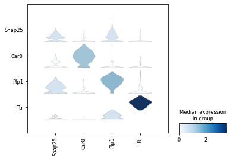

```python
# sc.pl.violin(adata, marker_list, groupby="clusters")
sc.pl.stacked_violin(adata, marker_list, groupby='clusters', figsize=(6,4), rotation=90)
```

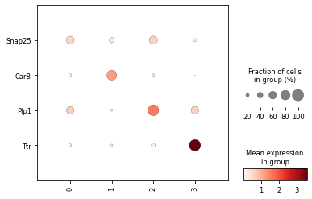

```python
sc.pl.dotplot(adata, marker_list, groupby = 'clusters', figsize=(6,4), swap_axes = True)
```

```python
# keep results
adata.write_csvs(results_file, )
```

##### Annotate clusters

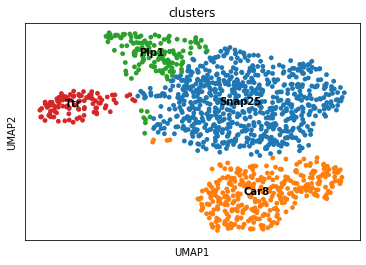

```python
adata.rename_categories("clusters", marker_list)
sc.pl.umap(adata, color="clusters", legend_loc="on data")
```

#### Supplement

Threshold setting to remove high mitochondrial genes: \ Regards to the highly mt-genes expressed, to investigate furtherly, run the same pipeline on the raw data. **(No filering)**

```python
# Log transformation
sc.pp.log1p(adata_raw)
```

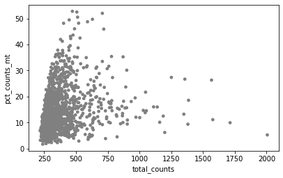

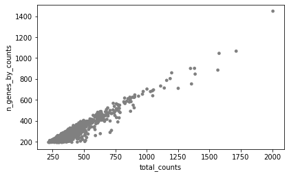

```python
sc.pl.scatter(adata_raw, x='total_counts', y='pct_counts_mt')
sc.pl.scatter(adata_raw, x='total_counts', y='n_genes_by_counts')
```

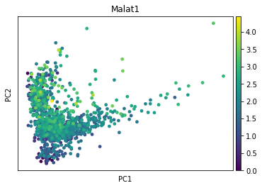

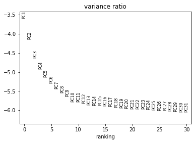

```python
# PCA
sc.tl.pca(adata_raw, svd_solver='arpack')
sc.pl.pca(adata_raw, color="Malat1") # coloring expression of a certain gene
sc.pl.pca_variance_ratio(adata_raw, log=True)
```

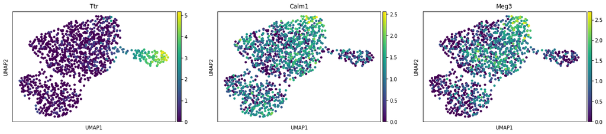

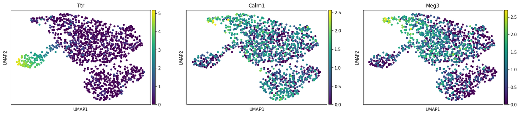

```python
# UMAP
sc.pp.neighbors(adata_raw, n_neighbors=10, n_pcs=40) # n_neighbors: The size of local neighborhood; default: 15
sc.tl.umap(adata_raw)
sc.pl.umap(adata_raw, color=['Ttr', 'Calm1', 'Meg3'], use_raw=False)

sc.pp.neighbors(adata_raw, n_neighbors=15, n_pcs=10)
sc.tl.umap(adata_raw)
sc.pl.umap(adata_raw, color=['Ttr', 'Calm1', 'Meg3'], use_raw=False)
#sc.pl.umap(adata, color=['Ttr', 'Calm1', 'Meg3'], use_raw=True)
#sc.pl.umap(adata_raw)
```

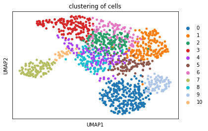

```python
# Leiden
sc.tl.leiden(adata_raw, key_added="clusters")
sc.pl.umap(adata_raw,color="clusters", title='clustering of cells')

#sc.tl.leiden(adata_raw, resolution=.5, key_added="clusters")
#sc.pl.umap(adata_raw,color="clusters", title='clustering of cells (resolution=0.5)')
```

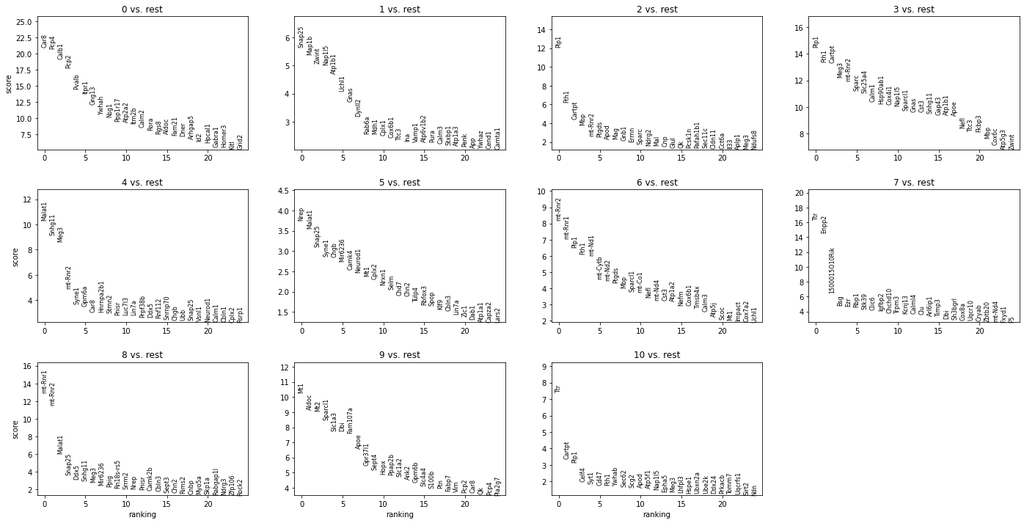

```python
# Scanpy recommending using Wilcoxon rank-sum (Mann-Whitney-U) test
sc.tl.rank_genes_groups(adata_raw, 'clusters', method='wilcoxon')
sc.pl.rank_genes_groups(adata_raw, n_genes=25, sharey=False)
```

```python
marker_list_raw = pd.DataFrame(adata_raw.uns['rank_genes_groups']['names']).iloc[0].tolist()
print(marker_list_raw)
# features overlap
```

```
['Car8', 'Snap25', 'Plp1', 'Plp1', 'Malat1', 'Nrep', 'mt-Rnr2', 'Ttr', 'mt-Rnr1', 'Mt1', 'Ttr']
```